# sel_2026

**Broadening the agent preference hypothesis through experiencers:**

**Eye-tracking and EEG evidence of proto-agents and proto-patients**

Marta Sánchez-López<sup>1</sup>

, Arrate Isasi-Isasmendi<sup>2</sup>

, Balthasar Bickel<sup>3</sup>

, Mikel Santesteban<sup>1</sup>

<sup>1</sup>University of the Basque Country (UPV/EHU), <sup>2</sup>Université de Pau et des Pays de l’Adour, <sup>3</sup>University of Zürich

[figure not shown]

[figure not shown]

[figure not shown]

[figure not shown]

# Index

- Introduction
- The present study
- Experiment 1
- Experiment 2
- Discussion
- References

# Introduction

Event roles

**Mary** danced.

⇩

Agent

**Mary** enjoyed.

⇩

Experiencer

**Thematic role list approaches**

Agent

Experiencer

Theme

Patient

Instrument

etc.

Fillmore (1971)

Agent  
Experiencer

Theme

Patient

Instrument

Rissman & Majid (2019)

Previous studies show:

- An attentional preference toward agents  
  Gómez-Vidal et al. (2022)
- A preference to transiently interpret the first unmarked noun in a sentence as an agent crosslinguistically  
  Bickel et al. (2015), Bornkessel & Schlesewsky (2006), Erdocia et al. (2009)

**The Agent preference**

N400 effect - recategorization of event role.

Bickel et al. (2015), Haupt et al. (2008), Sauppe et al. (2023), *inter alia*.

# The present study

Do experiencers display specific processing correlates?

Thematic role list approaches:

**Experiencer**

Agent

Patient

Fillmore (1971)

Proto-role approach:

**Proto-agent**

Proto-patient

Agent

(sentience, volition, causation)

Experiencer

(sentience)

Dowty (1991)

María bailó.

María disfrutó.

María vino.

⇩

Agent

⇩

Experiencer

⇩

Patient

**Thematic role list approaches**

María bailó.

María disfrutó.

María vino.

⇩

Agent

⇩

Experiencer

⇩

Patient

Fillmore (1971)

**Proto-role approach**

María bailó.

María disfrutó.

María vino.

⇩

Proto-agent

⇩

Proto-agent

⇩

Proto-patient

Dowty (1991)

# Experiment 1

**Eye-tracking reading experiment**

30 Spanish native speakers

96 experimental items and 96 fillers

**Experimental item**:

| Role | Subject Region | Preverb Region | Verb Region | Post-verb Region | Last-word Region |
| --- | --- | --- | --- | --- | --- |
| Agent | La conductora | el jueves | se esforzó | durante el | examen. |
| Experiencer | La conductora | el jueves | se sorprendió | durante el | examen. |
| Patient | La conductora | el jueves | se desorientó | durante el | examen. |

# Eye-tracking results

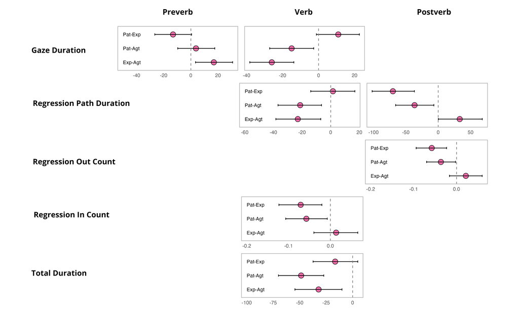

Our eye-tracking results show:

- **Agents** and **experiencers** involved longer fixation times and regression counts than **patients**.
- Differences between **agents** and **experiencers** varied depending on the measure and region.

# Experiment 2

**EEG reading experiment**

30 Spanish native speakers

96 experimental items and 96 fillers

# ERP results

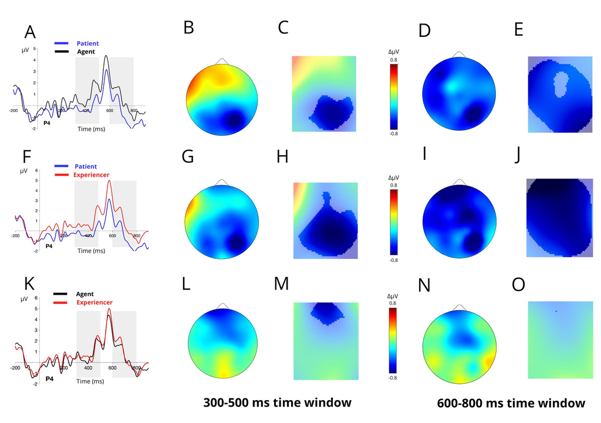

# TFA results

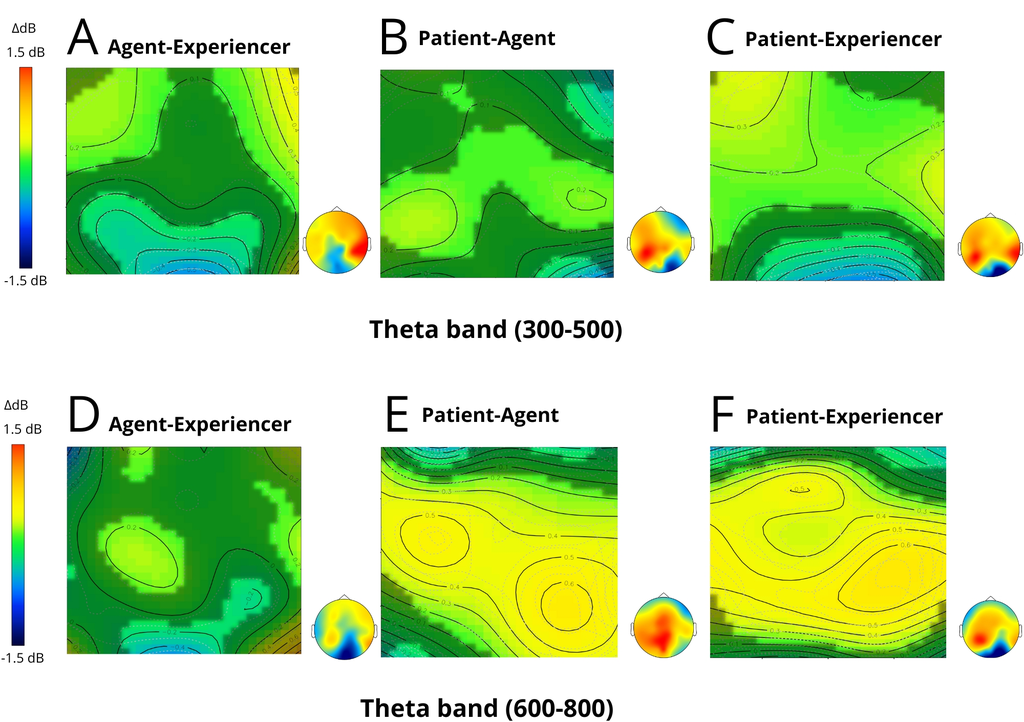

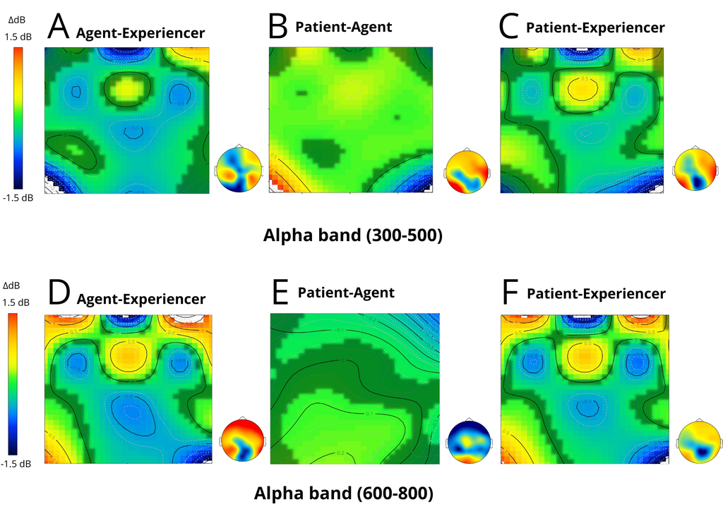

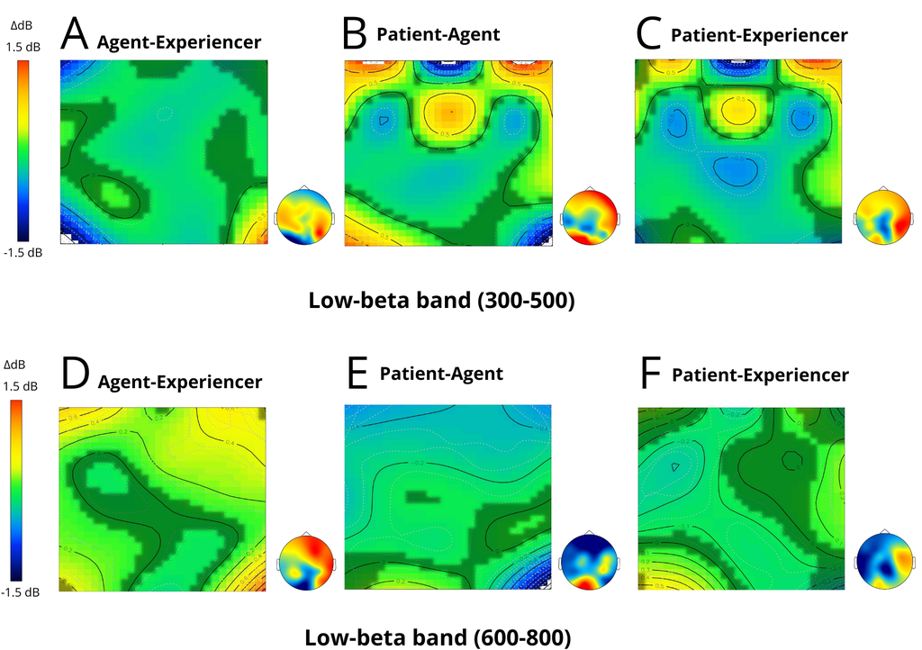

Our ERP results shows:

- In the early time window (300-500 ms): **patients** elicited a larger negativity compared to **agents** and **experiencers**.
- This negativity persits also in the late time window - sustained negativity.

Wang et al. (2012), Sauppe et al. (2023)

Our TFA results shows:

- This pattern of results also appeared in **theta band** in both time-windows: **patients** elicited a power increase compared to **agents** and **experiencers**, highly widespread in the late time-window.
- **In low beta**, **patients** revealed a power decrease compared to **agents** and **experiencers**, again in both time windows.

# Discussion

We found three patterns of results:

- An attentional preference to fixate **agents** and **experiencers**.
- A **recategorization** occurs when encountering verbs selecting **patient role**, whereas it did not appear with verbs selecting agent or experiencer roles.
- Prototypicality effects between **agents** and **experiencers**.

Evidence of **attentional preference** comes from:

-Higher fixation times of agents and experiencers compared to patients in late eye-tracking measures.

Gómez-Vidal et al. (2022)

Evidence of **recategorization** comes from:

-Elicitation of an N400 effect of patient roles compared to both agents and experiencers.

-Patients elicited a power increase in the theta band.

An increase in theta band appears with unexpected words and with semantic processing demands.

Klimesch (1999), Rommers et al. (2017)

A power decrease in alpha band is related to a release of inhibition and in low beta to a change in the current cognitive set, to upcoming words that do not match the predicted word, or to semantic violations.

Meyer (2018), Isasi-Isasmendi et al. (2023)

Evidence of **prototypicality** comes from:

-Experiencers involved longer fixation times than agents in the preverbal region in the Gaze Duration measure, but in the verb region, experiencers showed shorter fixation times than agents and patients in the same measure.

Gaze Duration is associated with early word recognition and lexical access processes.

Conklin et al. (2018)

-We found that agents involved larger fixation times than patients and experiencers in the verb region. However, in the postverbal region, this pattern shifted and both agents and experiencers showed longer fixation times than patients.

The delayed increase for experiencers may reflect a later categorization as proto-agents, due to their unique proto-agent entailment — the one of sentience.

Dowty (1991)

**Proto-role approach**

María bailó.

María disfrutó.

María vino.

⇩

Proto-agent

⇩

Proto-agent

⇩

Proto-patient

Dowty (1991)

¡Muchas gracias!

[figure not shown]

[figure not shown]

[figure not shown]

[figure not shown]

# References

Bickel, B., Witzlack-Makarevich, A., Choudhary, K. K., Schlesewsky, M., & Bornkessel-Schlesewsky, I. (2015). The neurophysiology of language processing shapes the evolution of grammar: Evidence from case marking. *PLOS ONE*, *10*(8), e0132819. https://doi.org/10.1371/journal.pone.0132819

Bornkessel, I., & Schlesewsky, M. (2006). The extended argument dependency model: A neurocognitive approach to sentence comprehension across languages. *Psychological Review*, *113*(4), 787–821. https://doi.org/10.1037/0033-295X.113.4.787

Conklin, K., Pellicer-Sánchez, A., & Carrol, G. (2018). *Eye-Tracking: A guide for applied linguistics research*. Cambridge University Press. https://doi.org/10.1017/9781108233279

Dowty, D. (1991). Thematic proto-roles and argument selection. *Language*, *67*(3), 547–619. https://doi.org/10.1353/lan.1991.0021

Erdocia, K., Laka, I., Mestres-Missé, A., & Rodriguez-Fornells, A. (2009). Syntactic complexity and ambiguity resolution in a free word order language: Behavioral and electrophysiological evidences from Basque. *Brain and Language*, *109*(1), 1–17. https://doi.org/10.1016/j.bandl.2008.12.003

Fillmore, C. J. (1971). Some problems for case grammar. In R. J. O’Brien (Ed.), *Report of the 22nd annual round table meeting on linguistics and language studies* (pp. 35–56). Georgetown University Press.

Gómez-Vidal, B., Arantzeta, M., Laka, J. P., & Laka, I. (2022). Subjects are not all alike: Eye-tracking the agent preference in Spanish. *PLOS ONE*, *17*(8). https://doi.org/10.1371/journal.pone.0272211

Haupt, F. S., Schlesewsky, M., Roehm, D., Friederici, A. D., & Bornkessel-Schlesewsky, I. (2008). The status of subject–object reanalyses in the language comprehension architecture. *Journal of Memory and Language*, *59*(1), 54–96. https://doi.org/10.1016/j.jml.2008.02.003

Isasi-Isasmendi, A., Sauppe, S., Andrews, C., Laka, I., Meyer, M., & Bickel, B. (2023). Incremental sentence processing is guided by a preference for agents: EEG evidence from Basque. *Language, Cognition and Neuroscience*, *39*(1), 76–97. https://doi.org/10.1080/23273798.2023.2250023

Klimesch, W. (1999). EEG alpha and theta oscillations reflect cognitive and memory performance: A review and analysis. *Brain Research Reviews*, *29*(2-3), 169–195. https://doi.org/10.1016/S0165-0173(98)00056-3

Meyer, L. (2018). The neural oscillations of speech processing and language comprehension: State of the art and emerging mechanisms. *European Journal of Neuroscience*, *48*(7), 2609–2621. https://doi.org/10.1111/ejn.13748

Rissman, L., & Majid, A. (2019). Thematic roles: Core knowledge or linguistic construct? *Psychonomic Bulletin & Review*, *26*(6), 1850–1869. https://doi.org/10.3758/s13423-019-01634-5

Rommers, J., Dickson, D. S., Norton, J. J. S., Wlotko, E. W., & Federmeier, K. D. (2017). Alpha and theta band dynamics related to sentential constraint and word expectancy. *Language, Cognition and Neuroscience*, *32*(5), 576–589. https://doi.org/10.1080/23273798.2016.1183799

Sauppe, S., Næss, Å., Roversi, G., Meyer, M., Bornkessel-Schlesewsky, I., & Bickel, B. (2023). An agent-first preference in a patient-first language during sentence comprehension. *Cognitive Science*, *47*(9, 9), e13340. https://doi.org/10.1111/cogs.13340

Wang, L., Jensen, O., Van Den Brink, D., Weder, N., Schoffelen, J., Magyari, L., Hagoort, P., & Bastiaansen, M. (2012). Beta oscillations relate to the N400m during language comprehension. *Human Brain Mapping*, *33*(12), 2898–2912. https://doi.org/10.1002/hbm.21410